# Milo on disease VS healthy dataset

```r
suppressPackageStartupMessages({
  library(tidyverse)
  library(irlba)
  library(DropletUtils)
  library(scater)
  library(scran)
  library(Seurat) ## just 4 loading the object
  library(SingleCellExperiment)
  library(miloR)
  library(patchwork)
  library(igraph)
  })
```

```
There were 24 warnings (use warnings() to see them)
```

Using data from [Ramachandran et al. 2019](https://www.nature.com/articles/s41586-019-1631-3#Sec1) (GEO accessiion: GSE136103). The Seurat object was downloaded from https://datashare.is.ed.ac.uk/handle/10283/3433, upon request to the authors.

```r
load("/nfs/team205/ed6/data/Ramachandran2019_liver/tissue.rdata")
```

```r
## Convert to SingleCellExperiment
liver_sce <- SingleCellExperiment(assay = list(counts=tissue@raw.data, logcounts=tissue@data),
                                  colData = tissue@meta.data)
```

### Feature selection

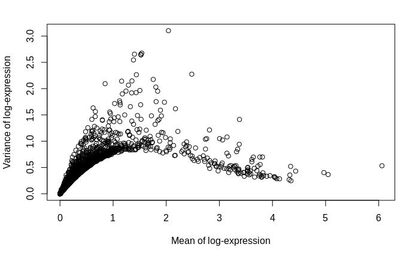

```r
dec_liver <- modelGeneVar(liver_sce)

# Visualizing the fit:
fit_liver <- metadata(dec_liver)
plot(fit_liver$mean, fit_liver$var, xlab="Mean of log-expression",
    ylab="Variance of log-expression")
```

```r
hvgs <- getTopHVGs(dec_liver, n=3000)
```

### Dim reduction

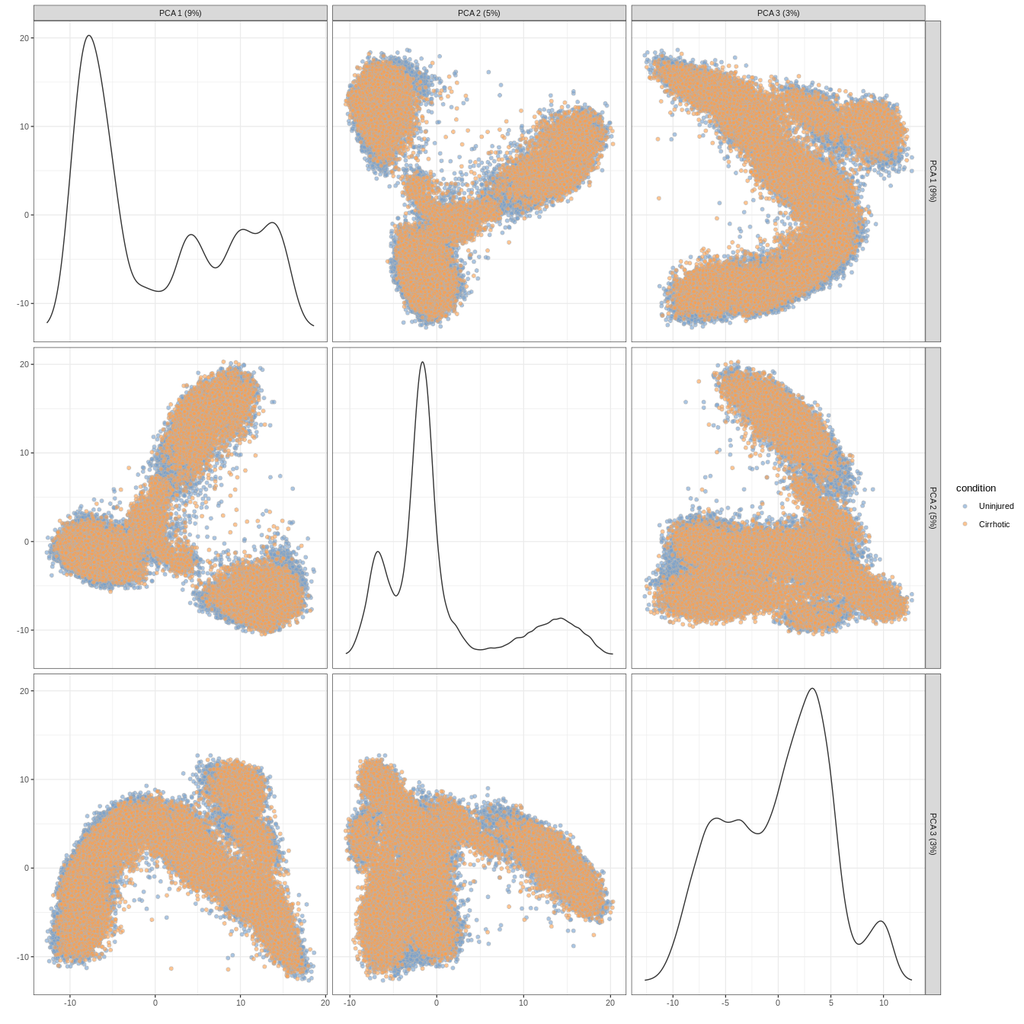

```r
liver_sce <- runPCA(liver_sce, subset_row=hvgs, ncomponents=11)

plotPCA(liver_sce, colour_by="condition", ncomponents=3)
```

```r
scater::plotUMAP(liver_sce, colour_by="condition", point_alpha=1,  point_size=0.5)
```

[output not shown]

### Apply Milo

Let’s test for differential abundance between healthy and cirrhotic livers.

#### Sample neighbourhoods

[figure not shown]

#### Make design matrix

```r
liver_meta <- as.tibble(colData(liver_milo)[,c("dataset","condition")])
```

```
`as.tibble()` is deprecated as of tibble 2.0.0.
Please use `as_tibble()` instead.
The signature and semantics have changed, see `?as_tibble`.
```

```r
liver_meta <- distinct(liver_meta) %>%
  mutate(condition=factor(condition, levels=c("Uninjured", "Cirrhotic"))) %>%
  column_to_rownames("dataset")
```

#### Test DA

```r
milo_res <- testNhoods(liver_milo, design = ~ condition, design.df = liver_meta, fdr.weighting = "k-distance")
```

```
Performing spatial FDR correction withk-distance weighting
```

```r
# liver_milo <- readRDS("/nfs/team205/ed6/data/Ramachandran2019_liver/tissue_milo.RDS")
# milo_res <- read_csv("/nfs/team205/ed6/data/Ramachandran2019_liver/milo_results.csv")
#
# liver_milo_2 <- Milo(as(liver_milo, 'SingleCellExperiment'))
#
# liver_milo_2@graph <- liver_milo@graph
# liver_milo@nhoodDistances <- liver_milo2@nhoodDistances
# liver_milo_2@graph <- liver_milo@graph
```

Visualize results

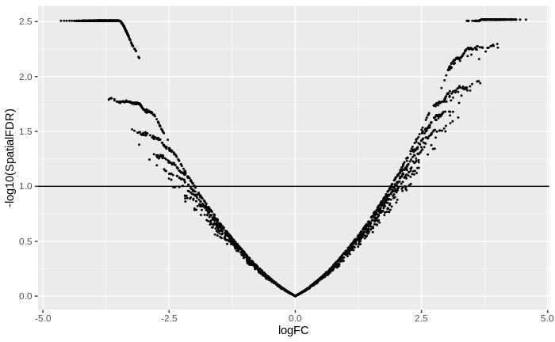

```r
milo_res %>%
  ggplot(aes(logFC, -log10(SpatialFDR))) +
  geom_point(size=0.4) +
  geom_hline(yintercept = -log10(0.1))
```

Check cell type composition of DA neighbourhoods

| logFC | logCPM | F | PValue | FDR | Nhood | SpatialFDR | annotation_indepth | annotation_indepth_fraction | annotation_lineage |
| --- | --- | --- | --- | --- | --- | --- | --- | --- | --- |
| 1.5085707047 | 18.74350 | 1.955561e+00 | 0.1619952302 | 0.245496987 | 1 | 0.242448210 | Mesenchyme (2) | 0.8285714 | Mesenchyme |
| 3.5680851433 | 18.18966 | 1.369976e+01 | 0.0002147189 | 0.003152958 | 2 | 0.003110079 | Tcells (2) | 1.0000000 | Tcells |
| -0.9607515098 | 18.18437 | 9.519020e-01 | 0.3292405006 | 0.426746341 | 3 | 0.422712975 | Tcells (1) | 0.3243243 | Tcells |
| 3.9694071558 | 18.49492 | 1.464774e+01 | 0.0001297524 | 0.003152958 | 4 | 0.003032833 | Plasma Bcells (2) | 0.9090909 | Plasma Bcells |
| -1.0609225693 | 18.21017 | 1.155538e+00 | 0.2823982756 | 0.377464428 | 5 | 0.373772394 | Tcells (4) | 0.8157895 | Tcells |
| -4.0587287505 | 18.74960 | 1.166423e+01 | 0.0006376548 | 0.003152958 | 6 | 0.003110079 | ILCs (1) | 0.9500000 | ILCs |
| -1.3109965235 | 18.06267 | 1.699440e+00 | 0.1923674093 | 0.280943952 | 7 | 0.277655386 | Cycling Tcells | 0.7812500 | Tcells |
| 1.0338641943 | 18.46587 | 1.077684e+00 | 0.2992215227 | 0.394667918 | 8 | 0.390905186 | Mesenchyme (2) | 0.9411765 | Mesenchyme |
| -3.6325494434 | 18.38336 | 1.146252e+01 | 0.0007107034 | 0.003152958 | 9 | 0.003110079 | Tcells (1) | 0.9038462 | Tcells |
| 1.7493788313 | 18.30105 | 3.165193e+00 | 0.0752298175 | 0.134763846 | 10 | 0.132504261 | MPs (8) | 0.9767442 | MPs |

[output cut: 990 more lines]

This shows that I can recover all the clusters where DA was detected in the original paper (see all the barplots for each lineage) and more! All in a single analysis, and without knowing where the subclusters are. Let’s bear in mind that positive logFC –> more cirrhotic, negative logFC —> more healthy

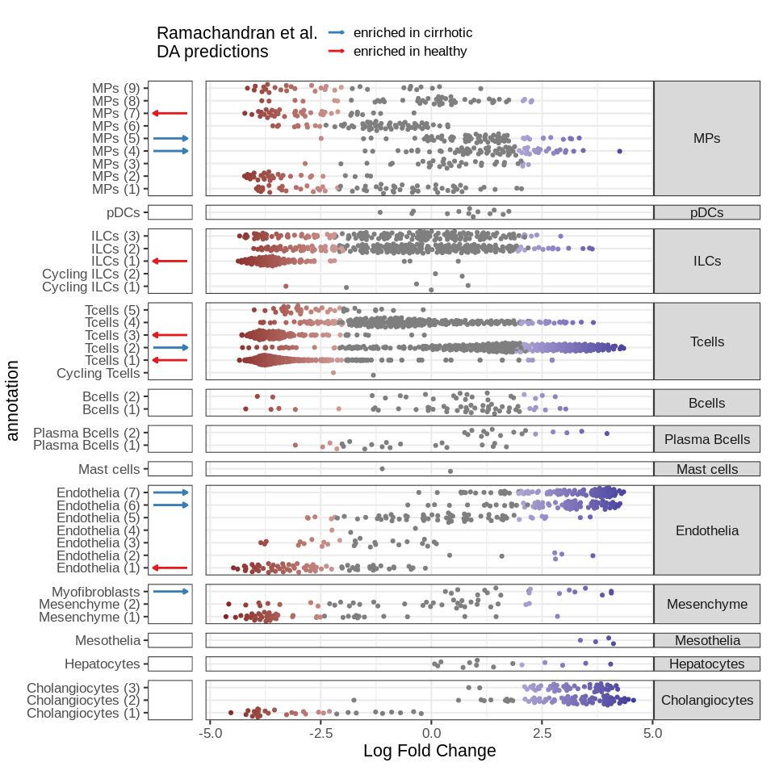

```r
paper_DA <- list(cirrhotic=c("MPs (4)","MPs (5)",
                             "Endothelia (6)", "Endothelia (7)",
                             "Mes (3)",
                             "Tcells (2)",
                             "Myofibroblasts"
                             ),
                 healthy=c("MPs (7)",
                           "Endothelia (1)",
                           "Tcells (1)", "Tcells (3)","Tcells (1)",
                           "ILCs (1)"
                           )
                 )

expDA_df <- bind_rows(
  data.frame(annotation_indepth = paper_DA[["cirrhotic"]], pred_DA="cirrhotic"),
  data.frame(annotation_indepth = paper_DA[["healthy"]], pred_DA="healthy")
  )

pl1 <- milo_res %>%
  left_join(expDA_df) %>%
  mutate(is_signif = ifelse(SpatialFDR < 0.1, 1, 0)) %>%
  mutate(logFC_color = ifelse(is_signif==1, logFC, NA)) %>%
  arrange(annotation_lineage) %>%
  mutate(Nhood=factor(Nhood, levels=unique(Nhood))) %>%
  ggplot(aes(annotation_indepth, logFC, color=logFC_color)) +
  scale_color_gradient2() +
  guides(color="none") +
  xlab("annotation") + ylab("Log Fold Change") +
  ggbeeswarm::geom_quasirandom(alpha=1) +
  coord_flip() +
  facet_grid(annotation_lineage~., scales="free", space="free") +
  theme_bw(base_size=16) +
  theme(strip.text.y =  element_text(angle=0),
        axis.title.y = element_blank(), axis.text.y = element_blank(), axis.ticks.y = element_blank(),
        )
pl2 <- milo_res %>%
  left_join(expDA_df) %>%
  # dplyr::filter(!is.na(pred_DA)) %>%
  group_by(annotation_indepth) %>%
  summarise(pred_DA=dplyr::first(pred_DA), annotation_lineage=dplyr::first(annotation_lineage)) %>%
  mutate(end=ifelse(pred_DA=="healthy", 0, 1),
         start=ifelse(pred_DA=="healthy", 1, 0)) %>%
  ggplot(aes(annotation_indepth, start, xend = annotation_indepth, yend = end, color=pred_DA)) +
  geom_segment(size=1,arrow=arrow(length = unit(0.1, "npc"), type="closed")) +
  coord_flip() +
  xlab("annotation") +
  facet_grid(annotation_lineage~.,
    # annotation_lineage~"Ramachandran et al.\nDA predictions",
             scales="free", space="free") +
  # guides(color="none") +
  scale_color_brewer(palette="Set1", direction = -1,
                     labels=c("enriched in cirrhotic", "enriched in healthy"),
                     na.translate = F,
                     name="Ramachandran et al.\nDA predictions") +
  guides(color=guide_legend(ncol = 1)) +
  theme_bw(base_size=16) +
  ylim(-0.1,1.1) +
  theme(strip.text.y = element_blank(),strip.text.x = element_text(angle=90),
        plot.margin = unit(c(0,0,0,0), "cm"), panel.grid = element_blank(),
        axis.title.x = element_blank(), axis.text.x = element_blank(), axis.ticks.x = element_blank(),
        legend.position = "bottom")
(pl2 + pl1 +
  plot_layout(widths=c(1,10), guides = "collect") & theme(legend.position = 'top', legend.justification = 0)) +
  ggsave("~/milo_output/liver_DAcomparison.pdf", width=8, height = 13)
```

### Visualization with nhood graph

```r
liver_milo <- buildNhoodGraph(liver_milo)
```

```
[1] "Calculating nhood adjacency...."
```

[figure not shown]

### Running Milo one lineage at the time

#### Endothelial lineage

Close up in the UMAP (I don’t recompute because it changes the underlying KNN graph, and I am not interested in doing this now)

```r
viz_df %>%
  filter(annotation_lineage=="Endothelia") %>%
  arrange(abs(logFC)) %>%
  ggplot( aes(X, Y)) +
    geom_point(aes(color = ''), size = pt_size / 3, alpha = 0.5) +
    geom_point(
      data = . %>% filter(!is.na(SpatialFDR)),
      aes(fill = logFC),
      size = pt_size,
      stroke = 0.1,
      # colour="black",
      shape = 21
    ) +
    scale_fill_gradient2(
      midpoint = 0,
      high = "red",
      low = "blue",
      name = "log-FC"
    ) +
    xlab(paste(nhood_reduced_dims, components[1], sep="_")) +
    ylab(paste(nhood_reduced_dims, components[2], sep="_")) +
    scale_color_manual(values = 'grey', label = paste("SpatialFDR >", round(filter_alpha, 2))) +
      guides(colour = guide_legend(
        '',
        override.aes = list(
          shape = 21,
          colour = "black",
          fill = "grey50",
          size = pt_size,
          alpha = 1,
          stroke = 0.1
        )
      )) +
    theme_classic(base_size = 16) +
    theme(
      axis.ticks = element_blank(),
      axis.text = element_blank(),
      plot.title = element_text(hjust = 0.5)
    )
```

[output not shown]

### Differential expression between DA neighbourhoods

I will try this on the endothelial lineage. I want to merge overlapping nhoods with significant DA and the same direction of logFC, and then test for differential expression between cells in up and down nhoods (I guess you could also do up or down VS all the rest). This allows us to perform a comparison without further clustering.

I roughly follow the method for marker detection described (here)[https://osca.bioconductor.org/marker-detection.html], using a Wilcoxon rank-sum test.

```r
endo_res <- filter(milo_res, annotation_lineage=="Endothelia")
```

```r
.group_nhoods_by_overlap <- function(nhs){
  ll_names <- expand.grid(names(nhs), names(nhs))

  lintersect <- sapply(1:nrow(ll_names), function(x) length(intersect(nhs[[ll_names[x,1]]], nhs[[ll_names[x,2]]])))
  ## Count as connected only nhoods with at least n shared cells
  n=3
  lintersect_filt <- ifelse(lintersect < n, 0, lintersect)

  ## Convert to adjacency matrix (values = no of common cells)
  d <- matrix(lintersect_filt, nrow = length(nhs), byrow = TRUE)

  g <- graph_from_adjacency_matrix(d)
  groups <- components(g)$membership
  return(groups)
}

.cells_in_nhood_groups <- function(nhs, gr){
  ls <- list()
  for (g in unique(gr)){
    nhs_ls <- lapply(nhs[which(gr==g)], function(x) as.vector(x))
    cells <- purrr::reduce(nhs_ls, union)
    ls[[g]] <- cells
  }
  return(ls)
}

## Get DA nhood with logFC > 0
pos_nhoods <- endo_res %>%
  filter(SpatialFDR < 0.1 & logFC > 1) %>%
  pull(Nhood)

## Get DA nhood with logFC < 0
neg_nhoods <- endo_res %>%
  filter(SpatialFDR < 0.1 & logFC < -1) %>%
  pull(Nhood)

## Collect cells in DA nhood
gr_neg <- .group_nhoods_by_overlap(nhoods(liver_milo)[neg_nhoods])
cells_ls <- .cells_in_nhood_groups(nhoods(liver_milo)[neg_nhoods], gr_neg)
neg_groups_df <- imap(cells_ls, ~ data.frame(cells_ix=.x, nhood_group=paste0("negLogFC_",.y))) %>%
  purrr::reduce(bind_rows)

gr_pos <- .group_nhoods_by_overlap(nhoods(liver_milo)[pos_nhoods])
cells_ls <- .cells_in_nhood_groups(nhoods(liver_milo)[pos_nhoods], gr_pos)
pos_groups_df <- imap(cells_ls, ~ data.frame(cells_ix=.x, nhood_group=paste0("posLogFC_",.y))) %>%
  purrr::reduce(bind_rows)

## Set up to test for marker genes
test_groups_df <- bind_rows(pos_groups_df, neg_groups_df) %>%
  group_by(cells_ix) %>%
  mutate(n=n()) %>%
  mutate(nhood_group=ifelse(n>1, NA, as.character(nhood_group))) %>% ## Exclude cells that are in multiple nhood groups
  ungroup()

colData(liver_milo)["test_groups"] <- NA
colData(liver_milo)[test_groups_df$cells_ix,"test_groups"] <- test_groups_df$nhood_group

endo_milo <- liver_milo[,which(colData(liver_milo)[["annotation_lineage"]]=="Endothelia")]

## Find HVGs for subset
dec_endo <- modelGeneVar(endo_milo)
endo_hvgs <- getTopHVGs(dec_endo, n=3000)

## Find marker genes with Wilcoxon rank sum test
markers <- findMarkers(endo_milo, groups=colData(endo_milo)$test_groups,
                       test.type="wilcox",
                       subset.row=endo_hvgs)

table(markers$negLogFC_2$FDR < 0.05)

head(data.frame(markers$negLogFC_2), 20)
head(data.frame(markers$negLogFC_1), 20)
head(data.frame(markers$posLogFC_1), 20)
```

[output not shown]

```r
disease_endo_markers <- c("ACKR1", 'CD34',"VWA1")

data.frame(markers$negLogFC_2) %>%
  filter(FDR < 0.05) %>%
  .[disease_endo_markers,]

data.frame(markers$negLogFC_1) %>%
  filter(FDR < 0.05) %>%
  .[disease_endo_markers,]
```

[output not shown]

Visualize some of the markers that differentiate DA neighbourhoods, by plotting the percent of cells expressing each gene in a nhood.

```r
## Define plotting functions
.calculate_nhood_perc_expression <- function(milo, nhoods, gene){
  gene_cnts <- counts(milo)[gene,]
  perc_expr <- sapply(nhoods(milo)[nhoods], function(x) sum(gene_cnts[x]>0)/length(x))
  perc_expr <- setNames(perc_expr, nhoods)
  return(perc_expr)
  }

.plot_nhood_expression <- function(milo, nhoods, features){
  perc_expr_mat <- sapply(features,
                          function(x) .calculate_nhood_perc_expression(milo, nhoods, x))

  pl_df <- data.frame(perc_expr_mat) %>%
    rownames_to_column("Nhood") %>%
    mutate(Nhood=as.double(Nhood)) %>%
    left_join(milo_res) %>%
    mutate(logFC_rank=rank(logFC))

  pl_top <- pl_df %>%
      mutate(is_signif = ifelse(SpatialFDR < 0.1, "SpatialFDR < 0.1", NA)) %>%
      ggplot(aes(logFC_rank, logFC)) +
      geom_hline(yintercept = 0, linetype=2) +
      geom_point(size=0.2) +
      geom_point(data=.%>% filter(!is.na(is_signif)), aes(color=is_signif), size=0.5) +
      theme_bw() +
      scale_color_manual(values="red", name="") +
      theme(axis.text.x = element_blank(), axis.ticks.x = element_blank(), axis.title.x = element_blank())

  pl_bottom <- pl_df %>%
    pivot_longer(cols=features, names_to='feature', values_to="perc_expressed") %>%
    mutate(feature=factor(feature, levels=features)) %>%
    ggplot(aes(logFC_rank, feature, fill=perc_expressed)) +
    geom_tile() +
    scale_fill_viridis_c(option="magma") +
    ggbio::theme_clear()

  (pl_top / pl_bottom) + plot_layout(heights = c(1,2))
}
```

```r
endo_nhoods <- endo_res %>%  pull(Nhood)

## Select genes and sort by AUC
feats_neg2 <-
  data.frame(markers$negLogFC_2) %>%
  top_n(50, - log10(FDR)) %>%
  arrange(AUC.posLogFC_1) %>%
  rownames()

.plot_nhood_expression(liver_milo, endo_nhoods, features=feats)
```

[output not shown]

```r
## Select genes and sort by AUC
feats_neg1 <-
  data.frame(markers$negLogFC_1) %>%
  top_n(50, - log10(FDR)) %>%
  arrange(AUC.posLogFC_1) %>%
  rownames()

.plot_nhood_expression(liver_milo, endo_nhoods, features=feats)
```

[output not shown]

```r
feats_neg1vsNeg2 <-
  data.frame(markers$negLogFC_1) %>%
  top_n(50, - log10(FDR)) %>%
  arrange(AUC.negLogFC_2) %>%
  rownames()

.plot_nhood_expression(liver_milo, endo_nhoods, features=feats_neg1vsNeg2)
```

[output not shown]